# Group Project 2

Knut Gjertsen

12/3/2017

## Data Cleaning

As part of our exploration of our dataset, we find several variables to be irrelevant to further analysis. The variables deleted are found irrelevant as they are aggregate variables or identical variables.

## Data Exploration:

### Structure of the Dataset:

The dataset includes a large amount of variables. Some of these variables are aggregate variables (made from a combination of other variables) and some do not make sense to include in the prediction model from a domain perspective. Also, some variables may not be relevant to our prediciton. After exploration and cleaning, we can use logistic regression to remove the variables with little to no influence.

```r
str(listings)
```

```
## 'data.frame':    33300 obs. of  51 variables:
##  $ number_of_days               : num  1095 1095 1095 296 1095 ...
##  $ principal_balance            : num  969 0 0 3636 0 ...
##  $ loan_status                  : num  0 1 0 1 0 0 0 0 0 0 ...
##  $ loan_status_description      : Factor w/ 4 levels "CHARGEOFF","COMPLETED",..: 3 4 2 1 2 2 3 2 2 2 ...
##  $ loan_origination_date        : Factor w/ 250 levels "1/10/2013","1/11/2013",..: 14 14 14 14 17 17 17 17 17 17 ...
##  $ amount_funded                : num  2000 2000 2000 4000 5500 10000 6500 3000 4000 2200 ...
##  $ prosper_rating               : Factor w/ 7 levels "A","AA","B","C",..: 3 5 6 7 1 3 3 5 5 5 ...
##  $ borrower_rate                : num  16.9 24.2 27.9 31.3 12.5 ...
##  $ listing_term                 : int  60 36 36 36 36 36 36 36 60 60 ...
##  $ listing_monthly_payment      : num  49.6 78.7 82.6 172.8 184 ...
##  $ scorex                       : Factor w/ 11 levels "< 600","600-619",..: 8 5 3 4 10 6 11 8 6 5 ...
##  $ prosper_score                : int  7 4 3 7 7 7 5 3 3 6 ...
##  $ listing_category_id          : int  13 13 1 2 1 1 1 1 1 1 ...
##  $ income_range                 : int  4 6 2 2 4 3 6 5 4 4 ...
```

[output cut: 37 more lines]

The variables that we can remove after exploration are: * income range * income_range_description * loan_status_description * loan origination date * Listing monthly payment (Can be calculated) * Occupation: High number of factors

# Analysis of Amount Funded

We begin by examining the distribution of amount funded for each succesful loan.

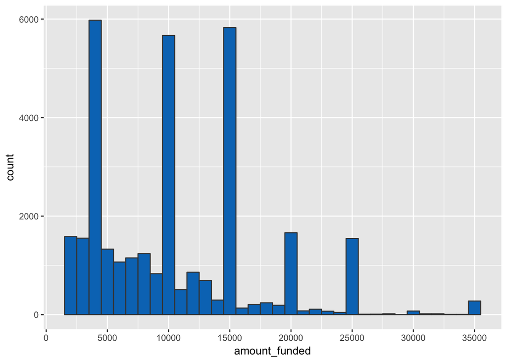

Here we plot the count for each amount funded. We find that the majority of the people are looking for smaller loans, and it trails out towards the upper limits of ~35,000. Another interesting thing to note is the spikes at each interval of 5000. ### Analysis of income range description

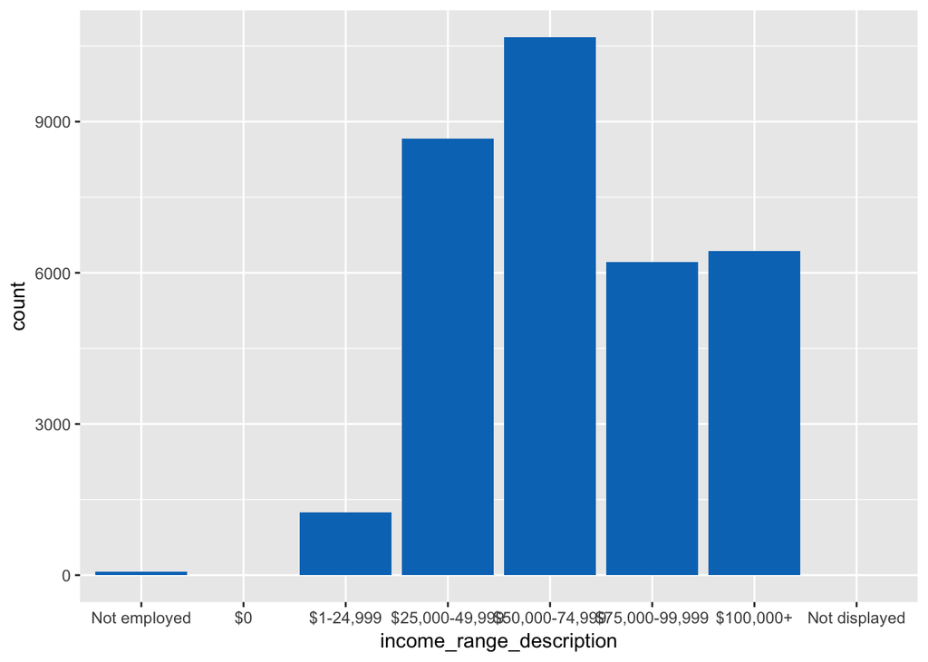

Here we plot the distribution of the income ranges for the borrowers. We find that it does not necessarily follow a normal distribution, with the majority of the borrows have less than 75,000.

For predictive purposes we will go ahead and assume that incomplete loans which are paid per schedule will be completed per schedule. Similarly, we will convert loans which are sold off to colleciton agencies as defaulted.

## Time Analysis

We look to explore how the the different variables differ over time.

### Analysis per Quarter

We will start by analysing the potential variation in the amount of loans taken and proportion of defaults among financial quarters.

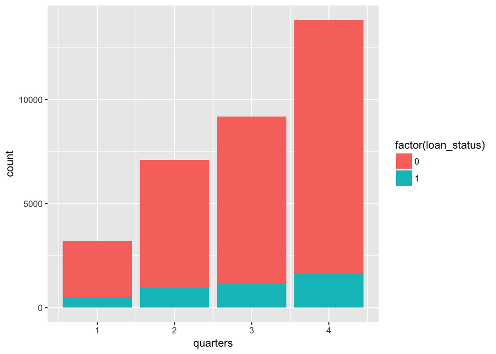

This bar chart is highly interesting, as it seems as if people tend to increasingly take out loans as the year progresses.

### Analysis By Monthly Quarter Exploration

Additionally, it seems as if the rate of default is lower as the year progresses, especially in the last financial quarter. To test this hypothesis we will calculate and plot the actual numbers for proportion of default.

```
## [1] 0.1611894
```

```
## [1] 0.1383878
```

```
## [1] 0.1266747
```

```
## [1] 0.1180214
```

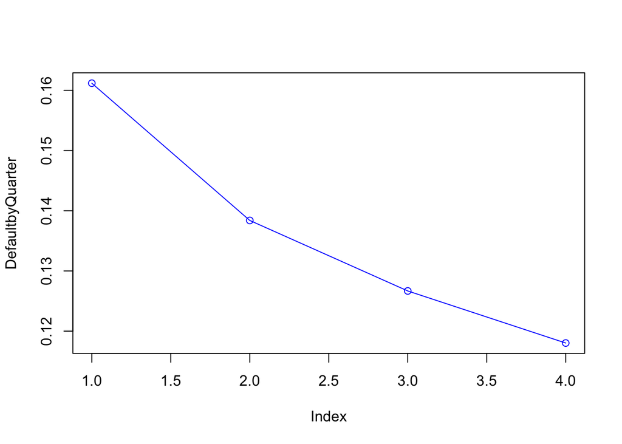

Here it becomes entirely clear to us that the rate of default substantially decreases with each financial quarter. This is a valuable finding which calls for further exploration.

### Default by Month Analysis

We will proceed by redoing the previous analysis per month. This could potentially show us whether certain months are drivers of the increased amount of loans and decreased default rates.

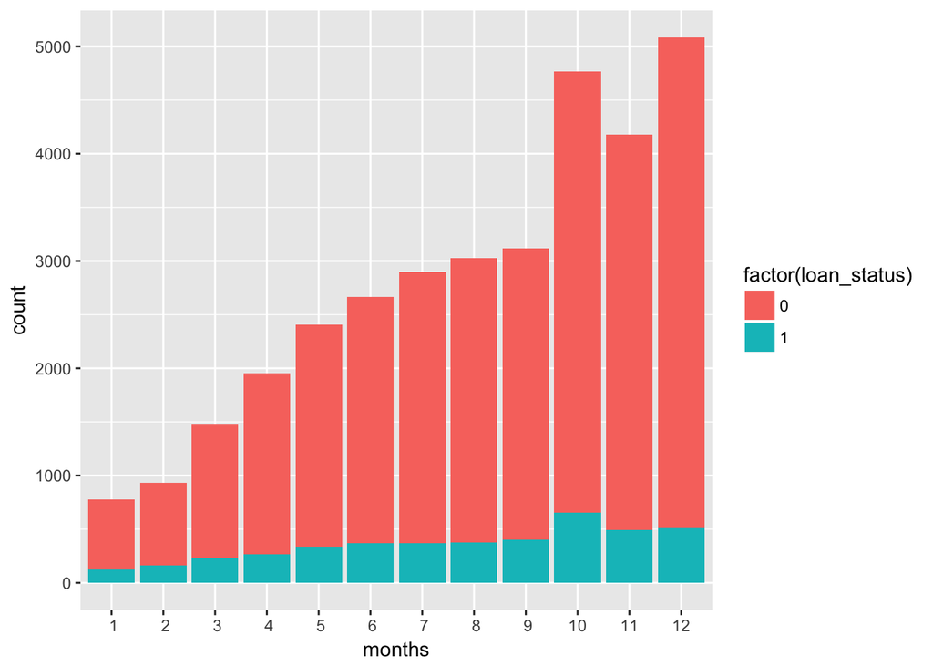

Let’s continue by calculating the default rates.

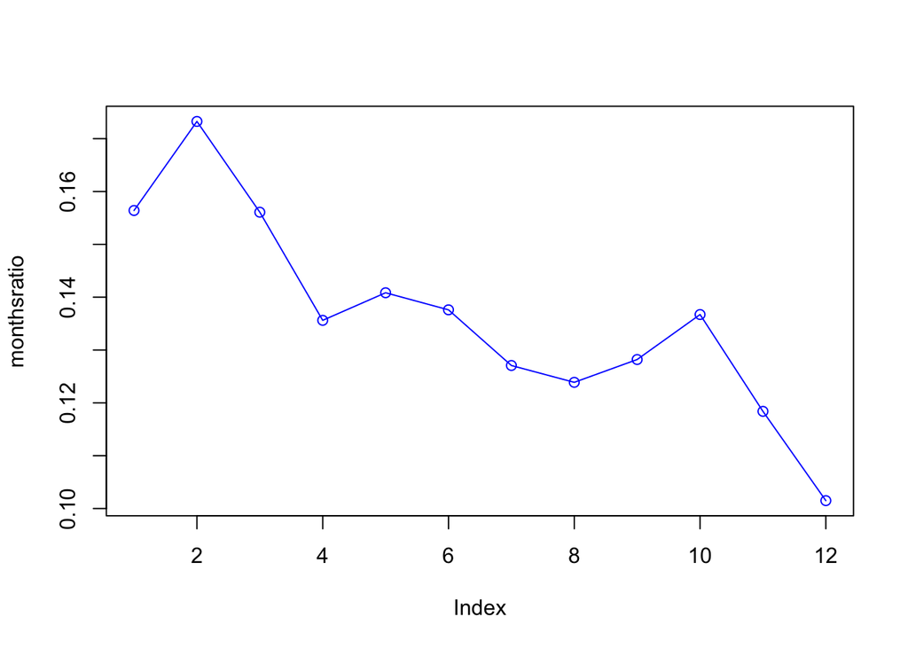

As suspected, the default rates of especially November and December are substantially lower than other months.

### Default Rate vs Borrow Rate vs Month: Arbitrage Opportunity

However, to check whether an investor would be able to find opportunity for arbitrage here, one would need to measure up the rate of default to the interest rate of loans. It could be that the months of November and December are simply filled with ideal loan candidates, demanding low borrowing rates. Let’s try to roughly estimate how the two match up over the year.

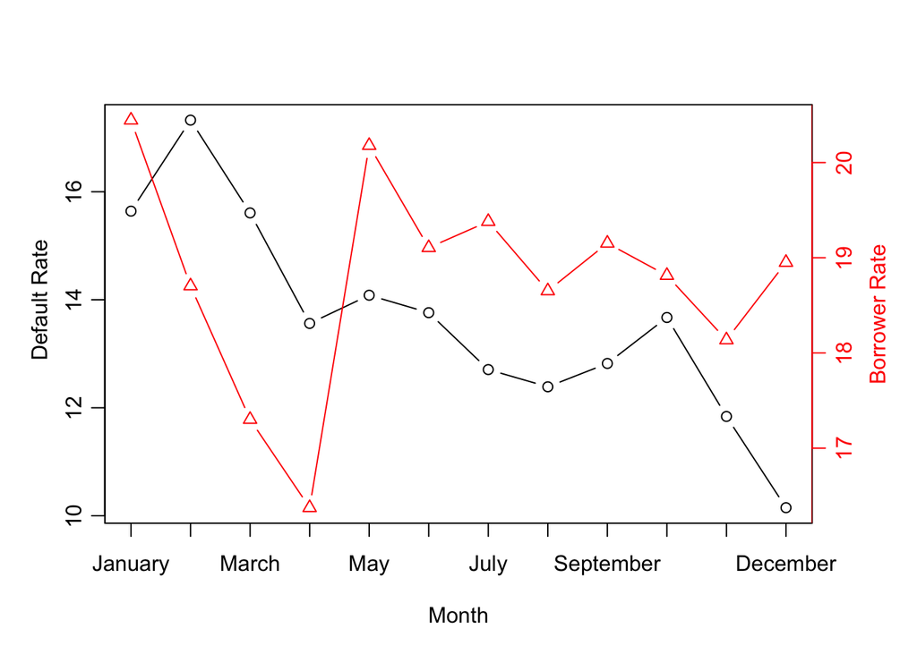

It here becomes clear to us that there does not seem to be a significant enough drop in borrowing rate for November and December to divert from investing in November and December. In conclusion, we believe to have found significant arbitrage opportunities for future investing.

### Analysis by Day of Week

As our previous analysis proved quite succesful, we will look towards further analysis how time might impact the default rate. This time we will further investigate the difference between weekdays and weekends.

We will start by labelling our date columns the name of each day.

```
##  Sun  Mon  Tue  Wed  Thu  Fri  Sat
##    0 5593 7293 7506 6355 6553    0
```

After splitting up and running a summation command we can see that the data set weirdly enough does not appear to include any Saturdays or Sundays. Upon re-inspecting the initial dataset, we could confirm that this was indeed the case.

We then proceed by comparing the different weekdays to each other. We start by investigating the difference in the rate of default.

```r
tapply(listings$loan_status, listings$day, mean)
```

```
##       Sun       Mon       Tue       Wed       Thu       Fri       Sat
##        NA 0.1260504 0.1290278 0.1316280 0.1323367 0.1246757        NA
```

The results show that there does not seem to be a significant difference in rate of default varying between weekdays.

Let’s run it for a few other variables to see if we can find any interesting results.

```r
tapply(listings$borrower_rate, listings$day, mean)
```

```
##      Sun      Mon      Tue      Wed      Thu      Fri      Sat
##       NA 18.32823 18.22340 18.37695 18.41558 18.28949       NA
```

```r
tapply(listings$amount_funded, listings$day, mean)
```

```
##      Sun      Mon      Tue      Wed      Thu      Fri      Sat
##       NA 10707.98 10504.51 10485.24 10576.31 10567.49       NA
```

```r
tapply(listings$income_range, listings$day, mean)
```

```
##      Sun      Mon      Tue      Wed      Thu      Fri      Sat
##       NA 4.220454 4.243933 4.248335 4.255862 4.241874       NA
```

```r
tapply(listings$income_verifiable, listings$day, mean)
```

```
##       Sun       Mon       Tue       Wed       Thu       Fri       Sat
##        NA 0.9309852 0.9362402 0.9385825 0.9345397 0.9420113        NA
```

```r
tapply(listings$monthly_debt, listings$day, mean)
```

```
##      Sun      Mon      Tue      Wed      Thu      Fri      Sat
##       NA 1094.321 1096.166 1110.861 1100.307 1110.160       NA
```

Disappoingly, there does not seem to be any significant differences between weekdays for these variables. We will thus not conduct further investigatiom into the difference between weekdays.

### Analysis By Scorex

Scorex is the credit score of the user, it goes from < 600, to 778+.

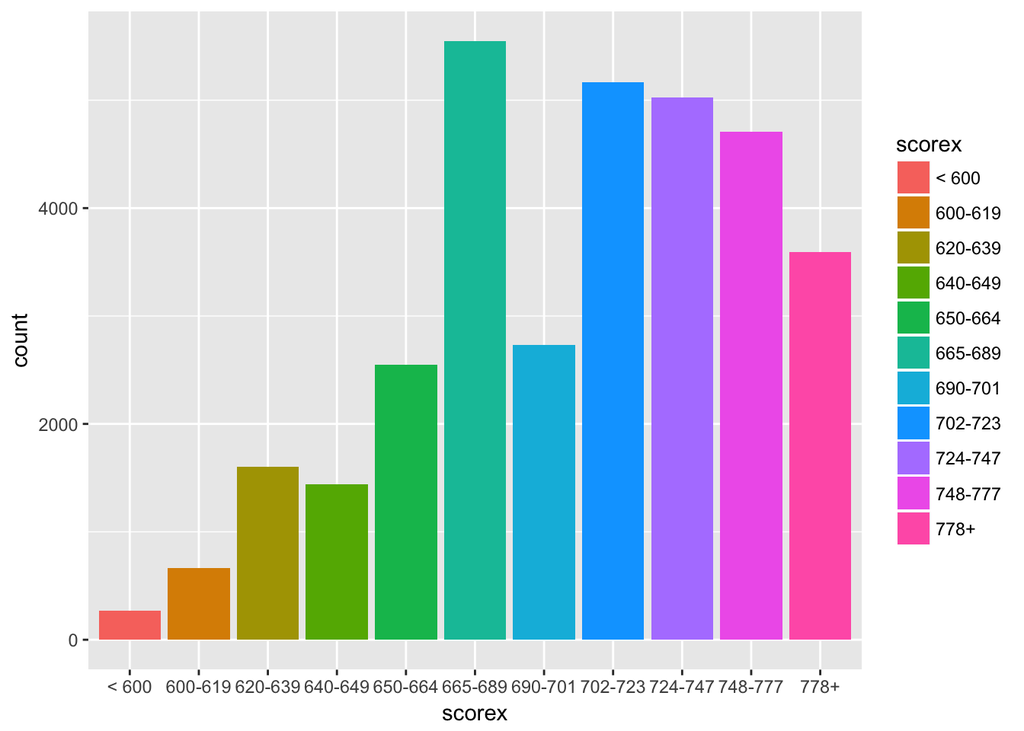

Default by Scorex

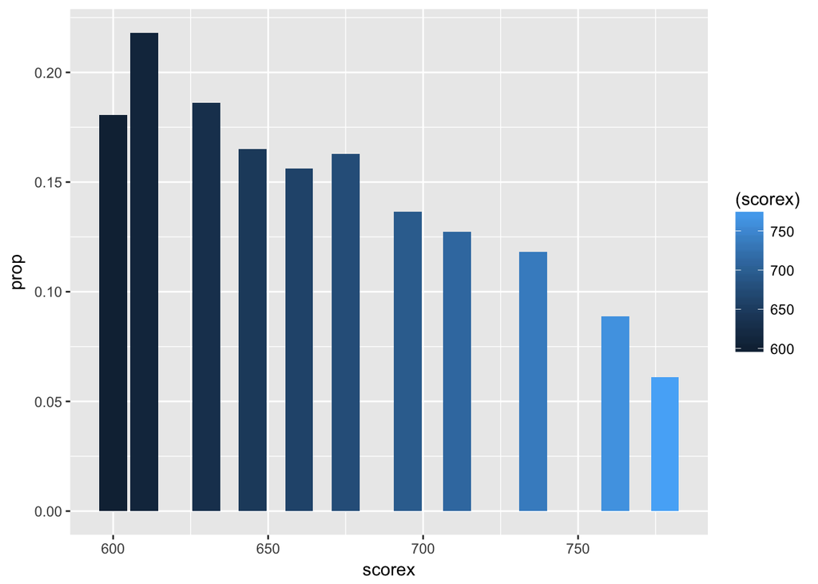

Scorex: As the scorex increases, the likelihood of defaulting decreases.

Prosper Score is a score from 1-11 with 1 being lowest risk. Because this is a score that we did not create we don’t know what went into it. In addition the data they are using is probably the same data we are using so it does not provide any novel new information to the model. Lets remove it.

```r
listings$prosper_score <- NULL
```

listings category ID is a category of the Loan but there is no description to go along with the IDs. This information might be useful though. NNot sure what to do with this.

Income range, Income Range Description, Stated Monthly Income. We don’t want this datapoint to be overrepresented in the model. Therefore we only need one of these variables. Lets go with Stated Monthly Income since it is more granular than the broad income range. TO DO: Some of the algorithms will find that they are highly correlated and won’t “Count them as double”… which ones?

### Analysis by Stated Monthly Income

```
##  num [1:33300] 4250 10833 1656 2000 4315 ...
```

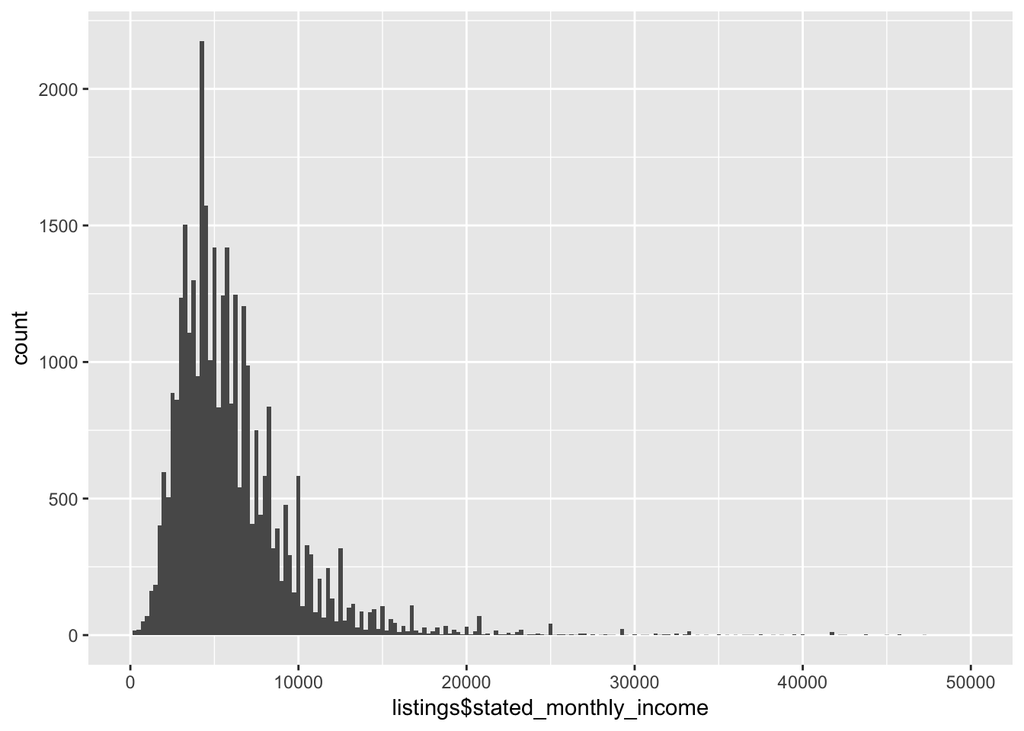

### Analyis of Income Verifiable

Income Verifiable, looks good and useful. Have to modify to be a factor first. Will be interested to see if it being verified has impact on default.

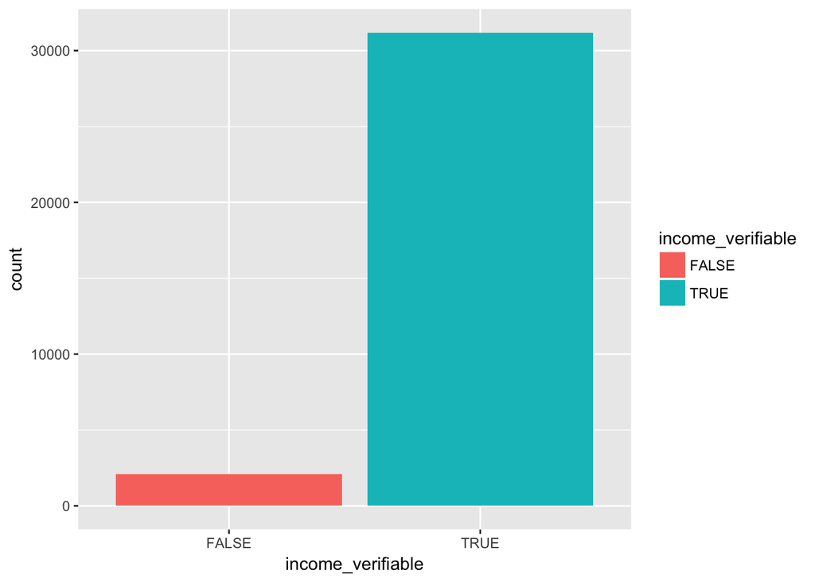

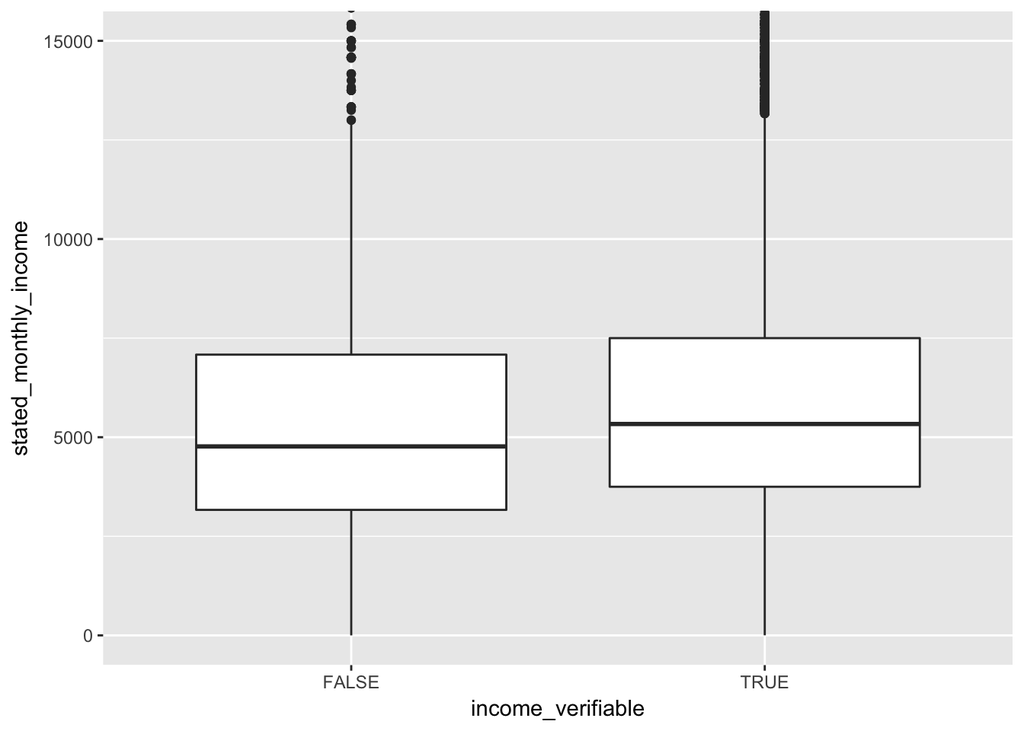

We find that there are many more people with their income verfied then not.

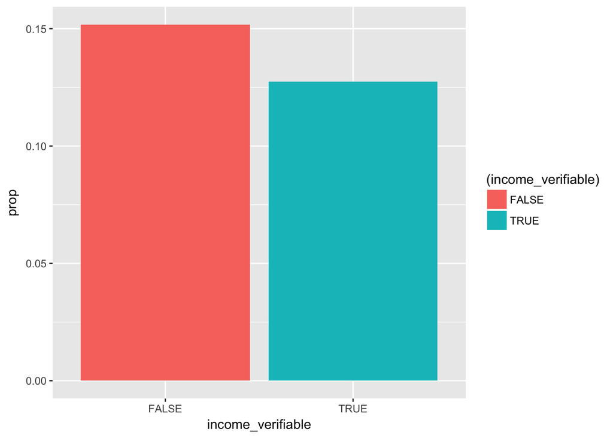

### Analysis by Employment Status Description & Employment.

There are blank values for occupation when someone chooses “Other for Employment Status Description”. Lets fix this.

```
##  Factor w/ 7 levels "Employed","Full-time",..: 1 1 4 2 1 1 7 1 1 1 ...
```

```
## [1] "Employed"      "Full-time"     "Not employed"  "Other"
## [5] "Part-time"     "Retired"       "Self-employed"
```

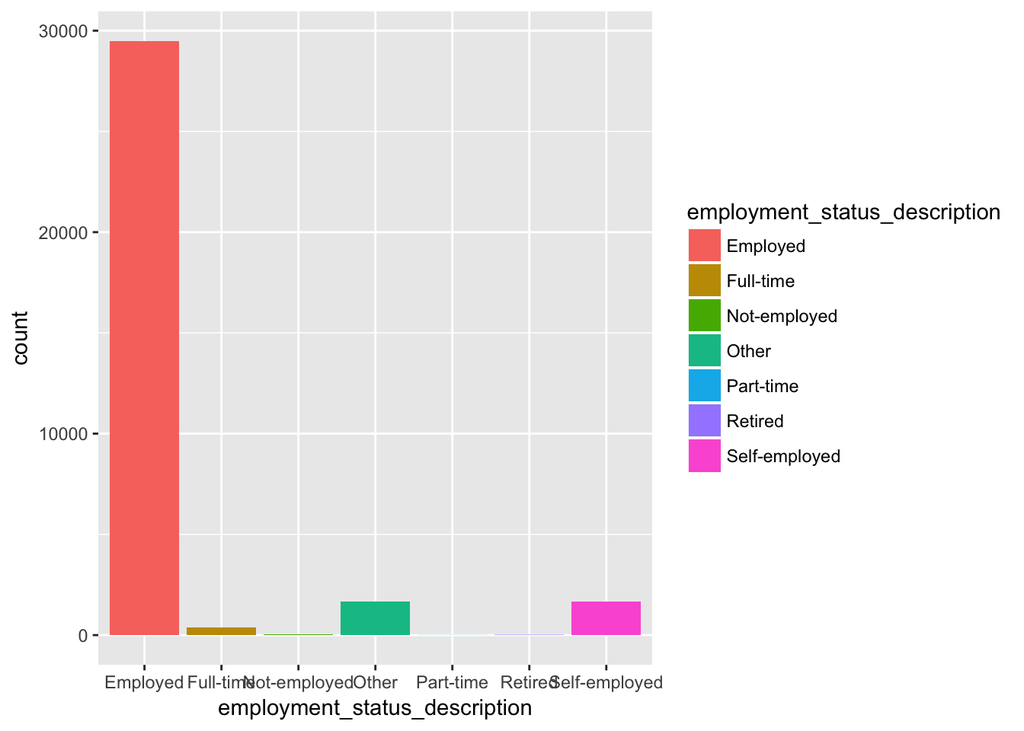

The majority are employed, self employed or other.

Months employed had values less than 0, we remove them and set it back to the median month.

```r
#
listings$months_employed[listings$months_employed <0] <- NA

listings$months_employed[is.na(listings$months_employed)] = median(listings$months_employed, na.rm=TRUE)
```

## Feature Engineering and Geographic Exploration

Since the data provideds use with borrow state, it would be interesting to explore the distribution of the geographic location.

### States by count of borrowers

[figure not shown]

We find that california is the most popular state, followed by texas and new york. This makes sense since they are the biggest states.

### States by Proportion of Default

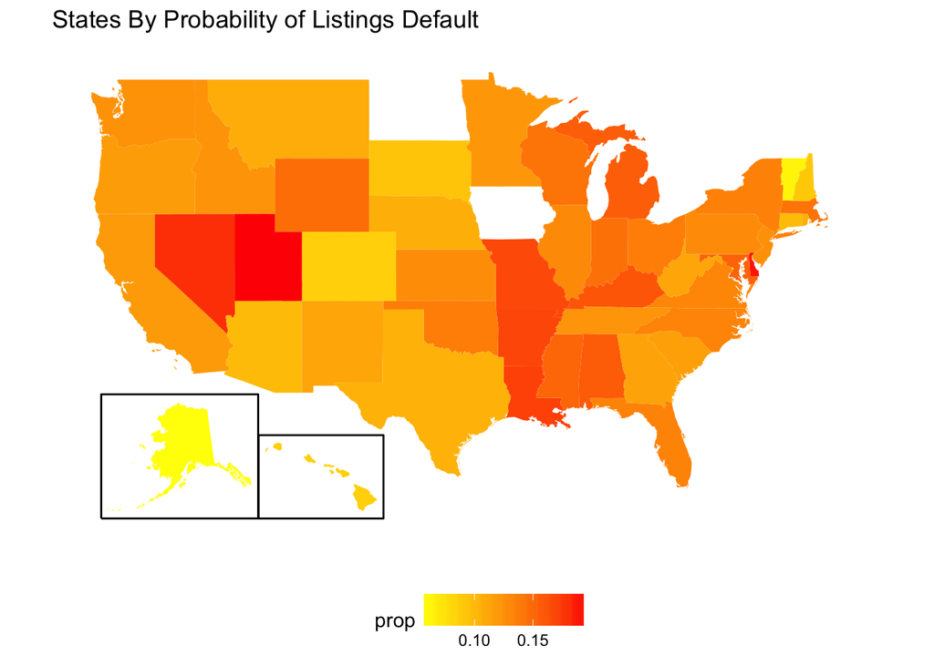

## Cost of Living By State

Since each state has a varying costs of living, we thought it would be interesting to explore if this has influence on the probability of default. We found a dataset bytheCouncil for Community & Economic Research (C2ER) that ranks each state by their Cost of living.

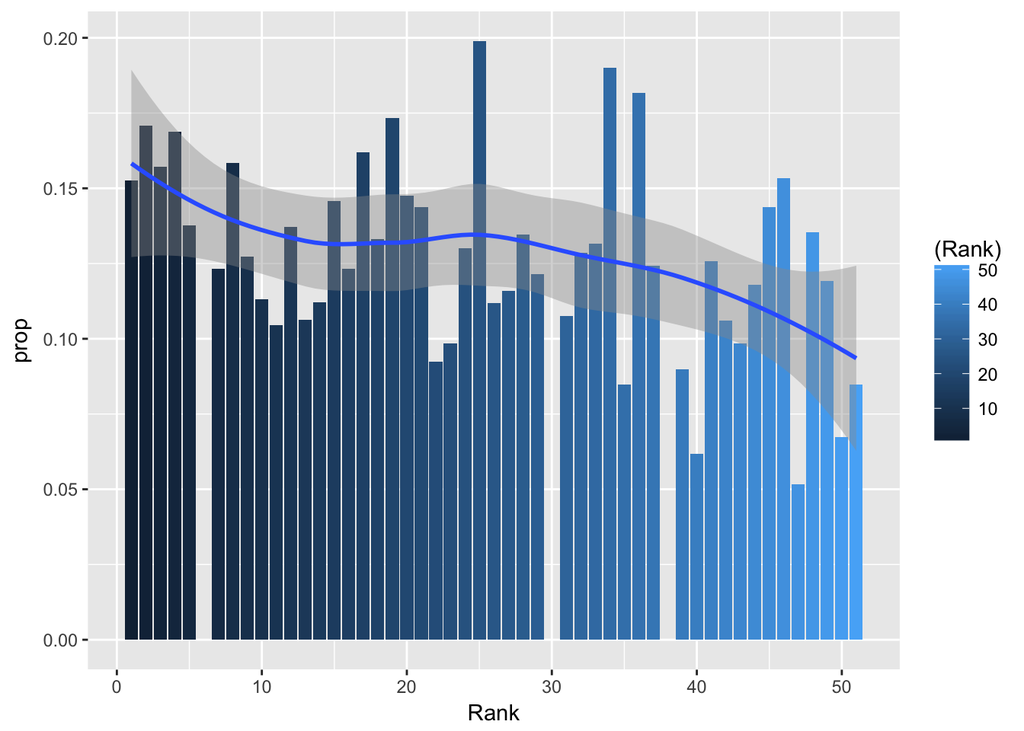

As the Cost of Living for each state rank goes up (less costly), likely hood of default goes down.

### Analysis by Borrower Rate

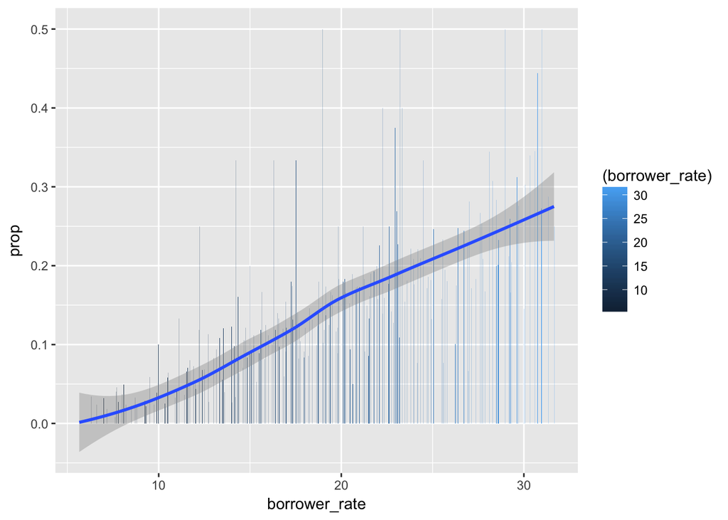

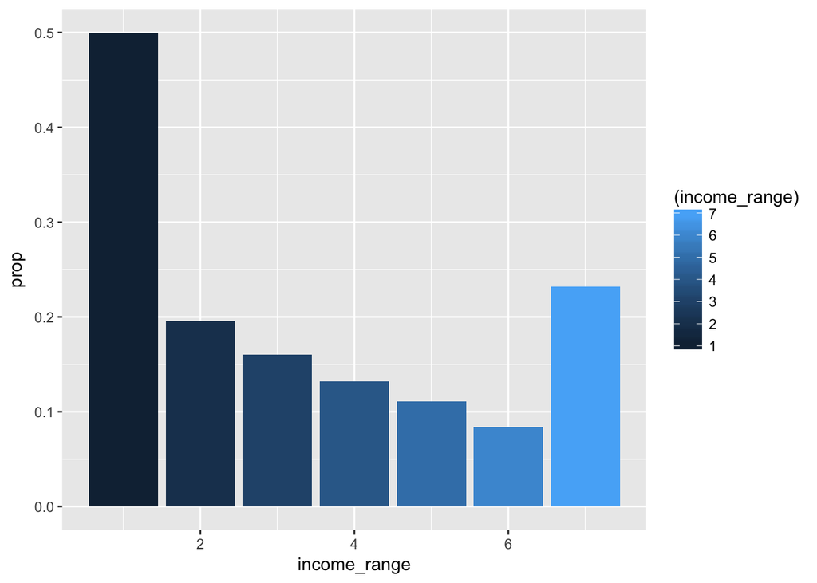

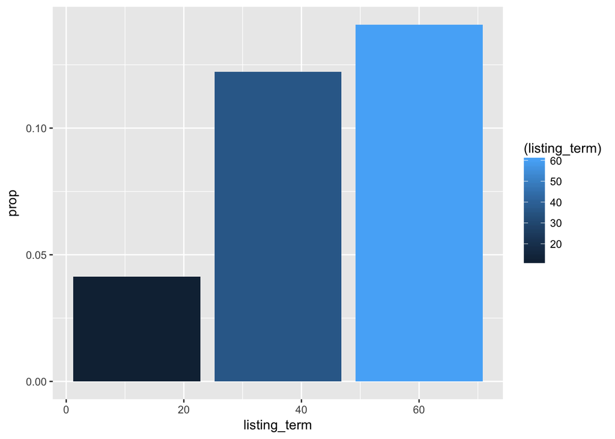

## Top 500 cities by GPD Analysis

Another aspect of location that we wanted to explore was cities. Since there were so many cities, we realized we needed to reduce this to a more measurable aspect. To do this, we took a dataset from Bureau of Economic Analysis which provided a list of the top 500 metropolotian areas with the best GDP. We parsed the cities from this and then created a new factor that marks each city as either major GDP or not major GDP.

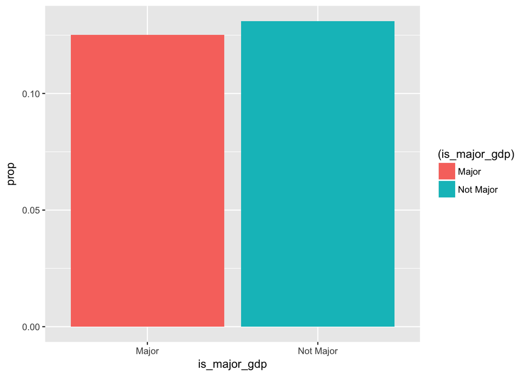

After separating the cities into two groups, either in the top 500 gpd producing metro’s or not major, we find little correlation.

### Aggregate Variable of delinquencies

```r
listings$delinq_agg <- listings$delinquencies_over30_days + 2*listings$delinquencies_over60_days + 4*listings$delinquencies_over90_days
```

# Final Cleaing of Variables

```r
#drop high factor level
#listingssample$borrower_city <- NULL
#listingssample$borrower_state <- NULL

# TODO: convert first_recorded to date
listings$borrower_rate <- NULL
listings$number_of_days <- NULL
listings$principal_balance <- NULL
listings$loan_status_description <- NULL
listings$loan_origination_date <- NULL
listings$listing_monthly_payment <- NULL
listings$listing_category_id <- NULL
listings$income_range <-NULL
listings$income_range_description <-NULL
listings$first_recorded_credit_line <- NULL

listings$months <- as.factor(listings$months)
listings$is_homeowner <-as.factor(listings$is_homeowner)
levels(listings$employment_status_description) <- c("Employed", "Fulltime", "NotEmployed", "other", "Parttime", "Retired", "SelfEmployed" )


listingsample<- listings[, !(colnames(listings) %in% c("State", "region", "originaldate", "borrower_city", "borrower_state", "occupation", "Rank", "delinquencies_over30_days", "delinquencies_over90_days", "delinquencies_over60_days"))]

#drop aggregates
#remove borrow_rate because its not includede in the bidding

listing_no_agg<- listingsample[, !(colnames(listingsample) %in% c("scorex", "dti_wprosper_loan", "prosper_rating"))]
```

# Data Prediction using Logistic Regression

```r
logReg <- glm(loan_status ~ ., data = listingsample, family = "binomial")
summary(logReg)
```

```
##
## Call:
## glm(formula = loan_status ~ ., family = "binomial", data = listingsample)
##
## Deviance Residuals:
##     Min       1Q   Median       3Q      Max
## -2.0592  -0.5818  -0.4608  -0.3332   3.7997
##
## Coefficients: (2 not defined because of singularities)
##                                             Estimate Std. Error z value
## (Intercept)                                7.690e-01  5.063e-01   1.519
## amount_funded                              3.325e-05  3.668e-06   9.065
## prosper_ratingAA                          -8.063e-01  1.674e-01  -4.816
## prosper_ratingB                            3.086e-01  6.867e-02   4.494
## prosper_ratingC                            7.027e-01  6.717e-02  10.461
## prosper_ratingD                            1.013e+00  7.491e-02  13.526
## prosper_ratingE                            1.275e+00  8.140e-02  15.660
## prosper_ratingHR                           1.555e+00  1.065e-01  14.606
## listing_term                               7.971e-03  1.500e-03   5.314
## scorex                                    -4.365e-03  6.046e-04  -7.220
## stated_monthly_income                     -7.784e-05  7.966e-06  -9.771
## income_verifiableTRUE                     -3.451e-01  1.196e-01  -2.886
## dti_wprosper_loan                          1.562e-03  2.377e-03   0.657
## employment_status_descriptionFulltime     -1.066e-02  1.614e-01  -0.066
## employment_status_descriptionNotEmployed  -3.123e-01  3.295e-01  -0.948
## employment_status_descriptionother         1.876e-01  7.120e-02   2.635
## employment_status_descriptionParttime      1.602e-01  1.164e+00   0.138
## employment_status_descriptionRetired       1.142e-01  6.394e-01   0.179
## employment_status_descriptionSelfEmployed -1.205e-01  1.359e-01  -0.886
## months_employed                           -5.747e-04  1.815e-04  -3.166
## lender_indicator                          -1.760e-01  8.808e-02  -1.998
## monthly_debt                               1.073e-04  3.438e-05   3.121
## current_delinquencies                     -1.871e-01  3.517e-01  -0.532
## delinquencies_last7_years                 -6.001e-03  9.504e-03  -0.631
## public_records_last10_years                2.226e-02  2.541e-02   0.876
## public_records_last12_months               4.337e-02  9.378e-02   0.462
## credit_lines_last7_years                   1.686e-01  3.502e-01   0.482
## inquiries_last6_months                     3.727e-02  1.595e-02   2.337
## amount_delinquent                          9.913e-07  2.189e-06   0.453
## current_credit_lines                      -2.644e-03  1.348e-02  -0.196
```

[output cut: 90 more lines]

```
## day.Q                                      0.23550
## day.C                                      0.73955
## day^4                                      0.89869
## is_major_gdpNot Major                      0.09417 .
## delinq_agg                                 0.62819
## ---
## Signif. codes:  0 '***' 0.001 '**' 0.01 '*' 0.05 '.' 0.1 ' ' 1
##
## (Dispersion parameter for binomial family taken to be 1)
##
##     Null deviance: 25592  on 33299  degrees of freedom
## Residual deviance: 24157  on 33240  degrees of freedom
## AIC: 24277
##
## Number of Fisher Scoring iterations: 6
```

```
Comments -

the following variables are stastically significant and have a fairly strong impact on on our response variable, loan_status -
1. amount_funded
2. listing_term
3. scorex
4. stated_monthly_income
5. income_verifiableTRUE
6. employment_status_descriptionother
7. months_employed
8. monthly_debt
9. inquiries_last6_months
10. total_open_revolving_accounts
11. installment_balance

Most of these are summary variables and their presence masks the impact other variables can have on loan_status.
As a result, we will run another regression without these summary variables
```

```r
logReg_revised <- glm(loan_status ~ . ,
                      data = listing_no_agg, family = "binomial")
summary(logReg_revised)
```

```
##
## Call:
## glm(formula = loan_status ~ ., family = "binomial", data = listing_no_agg)
##
## Deviance Residuals:
##     Min       1Q   Median       3Q      Max
## -3.8409  -0.5675  -0.4891  -0.3921   4.2618
##
## Coefficients: (2 not defined because of singularities)
##                                             Estimate Std. Error z value
## (Intercept)                               -1.108e+00  2.707e-01  -4.093
## amount_funded                              3.700e-06  3.362e-06   1.101
## listing_term                               1.104e-02  1.450e-03   7.611
## stated_monthly_income                     -1.054e-04  8.123e-06 -12.981
## income_verifiableTRUE                     -3.774e-01  1.186e-01  -3.182
## employment_status_descriptionFulltime     -9.763e-02  1.578e-01  -0.619
## employment_status_descriptionNotEmployed   1.649e-01  3.238e-01   0.509
## employment_status_descriptionother         1.752e-01  7.025e-02   2.494
## employment_status_descriptionParttime      6.089e-02  1.106e+00   0.055
## employment_status_descriptionRetired      -1.274e-01  6.345e-01  -0.201
## employment_status_descriptionSelfEmployed -1.851e-01  1.350e-01  -1.371
## months_employed                           -7.309e-04  1.803e-04  -4.055
## lender_indicator                          -4.337e-01  8.448e-02  -5.134
## monthly_debt                               2.177e-04  3.955e-05   5.504
## current_delinquencies                     -2.742e-01  3.537e-01  -0.775
## delinquencies_last7_years                 -1.340e-02  9.400e-03  -1.426
## public_records_last10_years                5.210e-02  2.433e-02   2.141
## public_records_last12_months               4.459e-02  9.140e-02   0.488
## credit_lines_last7_years                   3.048e-01  3.525e-01   0.865
## inquiries_last6_months                     1.184e-01  1.517e-02   7.807
## amount_delinquent                          2.987e-06  2.193e-06   1.362
## current_credit_lines                       2.546e-03  1.343e-02   0.190
## open_credit_lines                         -1.310e-02  1.528e-02  -0.857
## bankcard_utilization                       1.204e-01  1.082e-01   1.112
## total_open_revolving_accounts              3.180e-02  8.575e-03   3.709
## installment_balance                        1.471e-06  5.525e-07   2.662
## real_estate_balance                       -3.895e-07  2.354e-07  -1.655
## revolving_balance                         -2.215e-06  9.381e-07  -2.361
## real_estate_payment                       -1.052e-05  2.464e-05  -0.427
## revolving_available_percent               -5.333e-03  1.271e-03  -4.196
```

[output cut: 74 more lines]

```
## day.Q                                     0.219191
## day.C                                     0.645690
## day^4                                     0.920544
## is_major_gdpNot Major                     0.072159 .
## delinq_agg                                0.184532
## ---
## Signif. codes:  0 '***' 0.001 '**' 0.01 '*' 0.05 '.' 0.1 ' ' 1
##
## (Dispersion parameter for binomial family taken to be 1)
##
##     Null deviance: 25592  on 33299  degrees of freedom
## Residual deviance: 24791  on 33248  degrees of freedom
## AIC: 24895
##
## Number of Fisher Scoring iterations: 5
```

[output not shown]

# Getting Data Ready for Machine Learning Models

Since our dataset is relatively small ~33,300 after cleaning and the proportion of our predictor variable is low ~13%, we refine our dataset to have a more equal distribution of the two outcomes. This will help prevent overfitting or poor classification results. From our datset, about 4292 default and 29008 do not default.

```r
default_listings <- listingsample[listingsample$loan_status == 1, ]
no_default_listings <- listingsample[listingsample$loan_status == 0, ]

index <- sample(1:nrow(no_default_listings), 8600)


no_default_listings_sample <- no_default_listings[index, ]

listingsample <- rbind(no_default_listings_sample, default_listings)
```

```r
# Randomizing  dataset
set.seed(12345)
listing_rand <- listingsample[order(runif(12892)),]
#listing_rand$loan_status <- as.factor(listing_rand$loan_status)
loan_status <- listing_rand[1]


l_dummy <-model.matrix(~ . -1, data = listing_rand[-1])
l_dummy <- as.data.frame(scale(l_dummy))
l_dummy<- cbind(loan_status, l_dummy)
#normalize <- function(x) {
#  return ((x - min(x)) / (max(x) - min(x)))
#}
#l_dummy <- as.data.frame(lapply(l_dummy, normalize))
#l_dummy<- cbind(loan_status, l_dummy)



#library(plyr)
#l_dummy<- rename(l_dummy, c("beta"="two", "gamma"="three"))
names(l_dummy)[names(l_dummy)=="scorex< 600"] <- "scorexLess"

names(l_dummy)[names(l_dummy)=="scorex600-619"] <- "sx619"
names(l_dummy)[names(l_dummy)=="scorex620-639"] <- "sx639"
names(l_dummy)[names(l_dummy)=="scorex640-649"] <- "sx649"
names(l_dummy)[names(l_dummy)=="scorex650-664"] <- "sx664"
names(l_dummy)[names(l_dummy)=="scorex665-689"] <- "sx689"
names(l_dummy)[names(l_dummy)=="scorex690-701"] <- "sx701"
names(l_dummy)[names(l_dummy)=="scorex702-723"] <- "sx723"
names(l_dummy)[names(l_dummy)=="scorex724-747"] <- "sx747"
names(l_dummy)[names(l_dummy)=="scorex748-777"] <- "sx777"
names(l_dummy)[names(l_dummy)=="scorex778+"] <- "sx778"

names(l_dummy)[names(l_dummy)=="day^4"] <- "day4"
names(l_dummy)[names(l_dummy)=="day^5"] <- "day5"
names(l_dummy)[names(l_dummy)=="day^6"] <- "day6"
names(l_dummy)[names(l_dummy)=="top_ten_gdpNot Major"] <- "nogdp"



train_data_indicies <- sample(1:nrow(l_dummy),
                              replace = F,
                              size = floor(nrow(l_dummy) * 0.8))

train_data <- l_dummy[train_data_indicies, ]
test_data <- l_dummy[-train_data_indicies, ]
#listings_random <- listings[sample(nrow(listings)),]

round(prop.table(table(train_data$loan_status)) * 100, 1)
```

```
##
##  0  1
## 67 33
```

```r
round(prop.table(table(test_data$loan_status)) * 100, 1)
```

```
##
##    0    1
## 65.6 34.4
```

```r
#listing_formula <- colnames(train_data) %>%
#    {paste(.[! . %in% "loan_status"], collapse = " + ")} %>%
#    paste("loan_status ~ ", .) %>%
#    as.formula()
```

# accuracy function

```r
accuracy <- function(predicted, trueval, model, hideoutput = F) {
  stopifnot(length(predicted) == length(trueval))
  result <- sum(predicted == trueval) / length(predicted)
  if (!hideoutput) {cat("Model:", model, "had", result, "accuracy\n")}
  return(result)
}
```

```r
#train_data$loan_status <- as.factor(train_data$loan_status)
```

## Support Vector Machines - vanilladot

```r
library(kernlab)
# Needs to be in a factor for SVM to be treated as a classification
train_data$loan_status <- as.factor(train_data$loan_status)
train_data$loan_status <- as.factor(train_data$loan_status)

# vanilladot - Implement Model
classifier_vanilladot <- ksvm(loan_status ~ ., data = train_data, kernel = "vanilladot")
# vanilladot - Make Prediction
prediction_vanilladot <- predict(classifier_vanilladot, test_data)

# vanilladot - See some results
prop.table(table(prediction_vanilladot, test_data$loan_status))
```

```
##
## prediction_vanilladot          0          1
##                     0 0.64094610 0.32221791
##                     1 0.01512214 0.02171384
```

```r
# vanilladot - Evaluate overall efficency
prop.table(table(prediction_vanilladot == test_data$loan_status))
```

```
##
##     FALSE      TRUE
## 0.3373401 0.6626599
```

```r
a8 = accuracy(prediction_vanilladot, test_data$loan_status, "Vanilla SVM", TRUE)
```

## SVM - rbfdot

```r
library(kernlab)

# Needs to be in a factor for SVM to be treated as a classification

# rbfdot
classifier_rbfdot <- ksvm(loan_status ~ ., data = train_data, kernel = "rbfdot")
prediction_rbfdot <- predict(classifier_rbfdot, test_data)
#See some results
prop.table(table(prediction_rbfdot, test_data$loan_status))
```

```
##
## prediction_rbfdot          0          1
##                 0 0.63551764 0.32144242
##                 1 0.02055060 0.02248934
```

```r
#Evaluate overall efficency
prop.table(table(prediction_rbfdot == test_data$loan_status))
```

```
##
##    FALSE     TRUE
## 0.341993 0.658007
```

```r
a9 = accuracy(prediction_vanilladot, test_data$loan_status, "rbfdot SVM", TRUE)
```

# Data Prediction using kNN

```r
knn_listing_pred <- knn(train = train_data, test = test_data,
                      cl = train_data$loan_status, k = 20)
                      # k = sqrt(population size: 33542) = 183
# confusion matrix
CrossTable(test_data$loan_status, knn_listing_pred,
           dnn = c('Actual Loan Status', 'Predicted Loan Status'))
```

```
##
##
##    Cell Contents
## |-------------------------|
## |                       N |
## | Chi-square contribution |
## |           N / Row Total |
## |           N / Col Total |
## |         N / Table Total |
## |-------------------------|
##
##
## Total Observations in Table:  2579
##
##
##                    | Predicted Loan Status
## Actual Loan Status |         0 |         1 | Row Total |
## -------------------|-----------|-----------|-----------|
##                  0 |      1595 |        97 |      1692 |
##                    |     9.350 |    64.392 |           |
##                    |     0.943 |     0.057 |     0.656 |
##                    |     0.708 |     0.297 |           |
##                    |     0.618 |     0.038 |           |
## -------------------|-----------|-----------|-----------|
##                  1 |       657 |       230 |       887 |
##                    |    17.836 |   122.831 |           |
##                    |     0.741 |     0.259 |     0.344 |
##                    |     0.292 |     0.703 |           |
##                    |     0.255 |     0.089 |           |
## -------------------|-----------|-----------|-----------|
##       Column Total |      2252 |       327 |      2579 |
##                    |     0.873 |     0.127 |           |
## -------------------|-----------|-----------|-----------|
##
##
```

```r
Kappa(table(knn_listing_pred, test_data$loan_status))
```

```
##             value     ASE     z Pr(>|z|)
## Unweighted 0.2377 0.01799 13.21 7.87e-40
## Weighted   0.2377 0.01799 13.21 7.87e-40
```

```r
a1 = accuracy(knn_listing_pred, test_data$loan_status, "KNN with k = 20", TRUE)
```

# Decision Tree

```r
default_decision_tree <- C5.0(train_data[-1], train_data$loan_status, trials = 3)

default_decision_tree
```

```
##
## Call:
## C5.0.default(x = train_data[-1], y = train_data$loan_status, trials = 3)
##
## Classification Tree
## Number of samples: 10313
## Number of predictors: 64
##
## Number of boosting iterations: 3
## Average tree size: 10.3
##
## Non-standard options: attempt to group attributes
```

```r
summary(default_decision_tree)
```

```
##
## Call:
## C5.0.default(x = train_data[-1], y = train_data$loan_status, trials = 3)
##
##
## C5.0 [Release 2.07 GPL Edition]      Mon Dec 11 20:25:25 2017
## -------------------------------
##
## Class specified by attribute `outcome'
##
## Read 10313 cases (65 attributes) from undefined.data
##
## -----  Trial 0:  -----
##
## Decision tree:
##
## prosper_ratingAA > -0.2078642: 0 (422/34)
## prosper_ratingAA <= -0.2078642:
## :...prosper_ratingA > -0.4259548: 0 (1620/295)
##     prosper_ratingA <= -0.4259548:
##     :...listing_term <= -2.774434: 0 (55/7)
##         listing_term > -2.774434:
##         :...prosper_ratingB > -0.5059848: 0 (2084/545)
##             prosper_ratingB <= -0.5059848:
##             :...prosper_ratingC > -0.6173795: 0 (2807/990)
##                 prosper_ratingC <= -0.6173795:
##                 :...months2 > -0.1777783:
##                     :...day5 <= 0.0687658: 1 (93/27)
##                     :   day5 > 0.0687658: 0 (40/15)
##                     months2 <= -0.1777783:
##                     :...amount_funded <= -1.034593: 0 (430/149)
##                         amount_funded > -1.034593:
##                         :...prosper_ratingHR <= -0.1921328:
##                             :...listing_term <= -0.7778947: 0 (1537/674)
##                             :   listing_term > -0.7778947:
##                             :   :...prosper_ratingD <= -0.4309001: 1 (341/147)
##                             :       prosper_ratingD > -0.4309001: 0 (615/286)
##                             prosper_ratingHR > -0.1921328:
##                             :...months9 > -0.3231423: 0 (42/15)
##                                 months9 <= -0.3231423:
```

[output cut: 67 more lines]

```
##   80.20% listing_term
##   59.89% prosper_ratingC
##   32.52% months2
##   32.24% was_delinquent_derog
##   30.95% amount_funded
##   27.22% revolving_available_percent
##   26.78% prosper_ratingHR
##    9.99% prosper_ratingD
##    2.61% months9
##    2.20% day.L
##    1.85% months6
##    1.29% day5
##
##
## Time: 0.7 secs
```

```r
##Evaluating model performance ----
default_decision_pred <- predict(default_decision_tree, test_data)

# cross tabulation of predicted versus actual classes

CrossTable(test_data$loan_status, default_decision_pred,
           dnn = c('Actual Loan Status', 'Predicted Loan Status'))
```

```
##
##
##    Cell Contents
## |-------------------------|
## |                       N |
## | Chi-square contribution |
## |           N / Row Total |
## |           N / Col Total |
## |         N / Table Total |
## |-------------------------|
##
##
## Total Observations in Table:  2579
##
##
##                    | Predicted Loan Status
## Actual Loan Status |         0 |         1 | Row Total |
## -------------------|-----------|-----------|-----------|
##                  0 |      1613 |        79 |      1692 |
##                    |     0.383 |     5.866 |           |
##                    |     0.953 |     0.047 |     0.656 |
##                    |     0.666 |     0.500 |           |
##                    |     0.625 |     0.031 |           |
## -------------------|-----------|-----------|-----------|
##                  1 |       808 |        79 |       887 |
##                    |     0.730 |    11.190 |           |
##                    |     0.911 |     0.089 |     0.344 |
##                    |     0.334 |     0.500 |           |
##                    |     0.313 |     0.031 |           |
## -------------------|-----------|-----------|-----------|
##       Column Total |      2421 |       158 |      2579 |
##                    |     0.939 |     0.061 |           |
## -------------------|-----------|-----------|-----------|
##
##
```

```r
Kappa(table(default_decision_pred, test_data$loan_status))
```

```
##              value     ASE     z  Pr(>|z|)
## Unweighted 0.05267 0.01344 3.918 8.916e-05
## Weighted   0.05267 0.01344 3.918 8.916e-05
```

```r
a2= accuracy(default_decision_pred, test_data$loan_status, "C5.0 Decision Tree", TRUE)
```

### Improving Decision Trees: Boosting and Cost Matrix

Lets attempt to improve your decision tree model by adding Adaptive Boosting for 10 trials.

```r
# creating a decision tree prediction model using 10 trials
Decision_Tree_Model_Bagged <- C5.0(train_data[-1], train_data$loan_status, trials = 10)

# create a factor vector of predictions on test data
Decision_Tree_Predict_Bagged <- predict(Decision_Tree_Model_Bagged, test_data)

# creating a proportion table to check model accuacy
prop.table(table(Decision_Tree_Predict_Bagged == train_data$loan_status))
```

```
##
##     FALSE      TRUE
## 0.3614855 0.6385145
```

```r
# cross tabulation of predicted v/s actual classes
CrossTable(test_data$loan_status, Decision_Tree_Predict_Bagged,
           dnn = c('Actual Loan Status', 'Predicted Loan Status'))
```

```
##
##
##    Cell Contents
## |-------------------------|
## |                       N |
## | Chi-square contribution |
## |           N / Row Total |
## |           N / Col Total |
## |         N / Table Total |
## |-------------------------|
##
##
## Total Observations in Table:  2579
##
##
##                    | Predicted Loan Status
## Actual Loan Status |         0 |         1 | Row Total |
## -------------------|-----------|-----------|-----------|
##                  0 |      1567 |       125 |      1692 |
##                    |     1.211 |    10.985 |           |
##                    |     0.926 |     0.074 |     0.656 |
##                    |     0.675 |     0.488 |           |
##                    |     0.608 |     0.048 |           |
## -------------------|-----------|-----------|-----------|
##                  1 |       756 |       131 |       887 |
##                    |     2.309 |    20.955 |           |
##                    |     0.852 |     0.148 |     0.344 |
##                    |     0.325 |     0.512 |           |
##                    |     0.293 |     0.051 |           |
## -------------------|-----------|-----------|-----------|
##       Column Total |      2323 |       256 |      2579 |
##                    |     0.901 |     0.099 |           |
## -------------------|-----------|-----------|-----------|
##
##
```

```r
Kappa(table(Decision_Tree_Predict_Bagged, test_data$loan_status))
```

```
##              value     ASE     z  Pr(>|z|)
## Unweighted 0.08885 0.01615 5.501 3.783e-08
## Weighted   0.08885 0.01615 5.501 3.783e-08
```

```r
a3= accuracy(default_decision_pred, test_data$loan_status, "C5.0 Decision Tree with 10 trials", TRUE)
```

Lets attempt to improve your model with a cost matrix.

```r
# cost matrix
Decision_Tree_Error_Cost_Matrix <- matrix(c(0, 1, 4, 0), nrow = 2)

# create model - apply the cost matrix to the tree
Decision_Tree_Error_Cost_Model <- C5.0(train_data[-1],
                                       train_data$loan_status,
                                       costs = Decision_Tree_Error_Cost_Matrix)
# predict - using model and test data set
Decision_Tree_Error_Cost_Prediction <- predict(Decision_Tree_Error_Cost_Model, test_data)


# creating a proportion table to check model accuacy
prop.table(table(Decision_Tree_Error_Cost_Prediction == train_data$loan_status))
```

```
##
##     FALSE      TRUE
## 0.5980801 0.4019199
```

```r
# cross tabulation of predicted v/s actual classes
CrossTable(test_data$loan_status, Decision_Tree_Error_Cost_Prediction,
           dnn = c('actual loan_status', 'predicted loan_status'))
```

```
##
##
##    Cell Contents
## |-------------------------|
## |                       N |
## | Chi-square contribution |
## |           N / Row Total |
## |           N / Col Total |
## |         N / Table Total |
## |-------------------------|
##
##
## Total Observations in Table:  2579
##
##
##                    | predicted loan_status
## actual loan_status |         0 |         1 | Row Total |
## -------------------|-----------|-----------|-----------|
##                  0 |       441 |      1251 |      1692 |
##                    |    21.229 |     5.622 |           |
##                    |     0.261 |     0.739 |     0.656 |
##                    |     0.817 |     0.614 |           |
##                    |     0.171 |     0.485 |           |
## -------------------|-----------|-----------|-----------|
##                  1 |        99 |       788 |       887 |
##                    |    40.495 |    10.725 |           |
##                    |     0.112 |     0.888 |     0.344 |
##                    |     0.183 |     0.386 |           |
##                    |     0.038 |     0.306 |           |
## -------------------|-----------|-----------|-----------|
##       Column Total |       540 |      2039 |      2579 |
##                    |     0.209 |     0.791 |           |
## -------------------|-----------|-----------|-----------|
##
##
```

```r
a4= accuracy(Decision_Tree_Error_Cost_Prediction, test_data$loan_status, "C5.0 Decision Tree with cost matrix", TRUE)
```

### Cross Validation

run a 10-fold cross validation in an attempt to improve the model -

```r
# randomizing the data set
set.seed(12345)
folds <- createFolds(train_data$loan_status, k = 10)

folding_results <- lapply(folds, function(x) {
  fold_train <- train_data[x, ]
  fold_test <- test_data[-x, ]
  fold_model  <- C5.0(loan_status ~ ., data = fold_train)
  prediction <- predict(fold_model, fold_test)
  actual <- fold_test$loan_status
  kappa <- kappa2(data.frame(actual, prediction))$value
  return(kappa)
})

str(folding_results)
```

```
## List of 10
##  $ Fold01: num 0.0679
##  $ Fold02: num 0.0326
##  $ Fold03: num 0.11
##  $ Fold04: num 0.0782
##  $ Fold05: num 0.066
##  $ Fold06: num 0.0977
##  $ Fold07: num 0.0671
##  $ Fold08: num 0.0363
##  $ Fold09: num 0.0703
##  $ Fold10: num 0.0965
```

```r
mean(unlist(folding_results))
```

```
## [1] 0.07225935
```

Random Forest:

```r
rf <- randomForest(loan_status ~ listing_term+stated_monthly_income+income_verifiableTRUE+employment_status_descriptionother+months_employed+monthly_debt+public_records_last10_years+inquiries_last6_months+total_open_revolving_accounts+installment_balance+revolving_available_percent+total_inquiries+scorex, data = train_data)
rf_pred <- predict(rf, test_data)
a7 = accuracy(rf_pred, test_data$loan_status, "Random Forest", TRUE)
Kappa(table(rf_pred, test_data$loan_status))
```

```
##              value     ASE     z  Pr(>|z|)
## Unweighted 0.04918 0.01473 3.338 0.0008451
## Weighted   0.04918 0.01473 3.338 0.0008451
```

```r
acc_predictions = c(a1,a2,a3,a4,a7,a8,a9 )
#acc_predictions = c(a1,a2,a3,a4,a5,a6,a7,a8,a9,a10)
names = c("KNN", "Decision Tree Regression","Decision Tree Regression with 10 trials", "Decision Tree Regression with Cost Matrix", "Random Forest","SVM with Vanilla Kernal","SVM Radial Basis Kernal")

#names = c("Knn","Decision C5.0 Tree Regression","Decision Tree C5.0 Regression trails 10", "Decision Tree C5.0 with Cost Model", "Random Forest", "Stacked Model")

acc_mat <- data.frame(ModelName = names, accuracy = acc_predictions) %>% print
```

[output not shown]

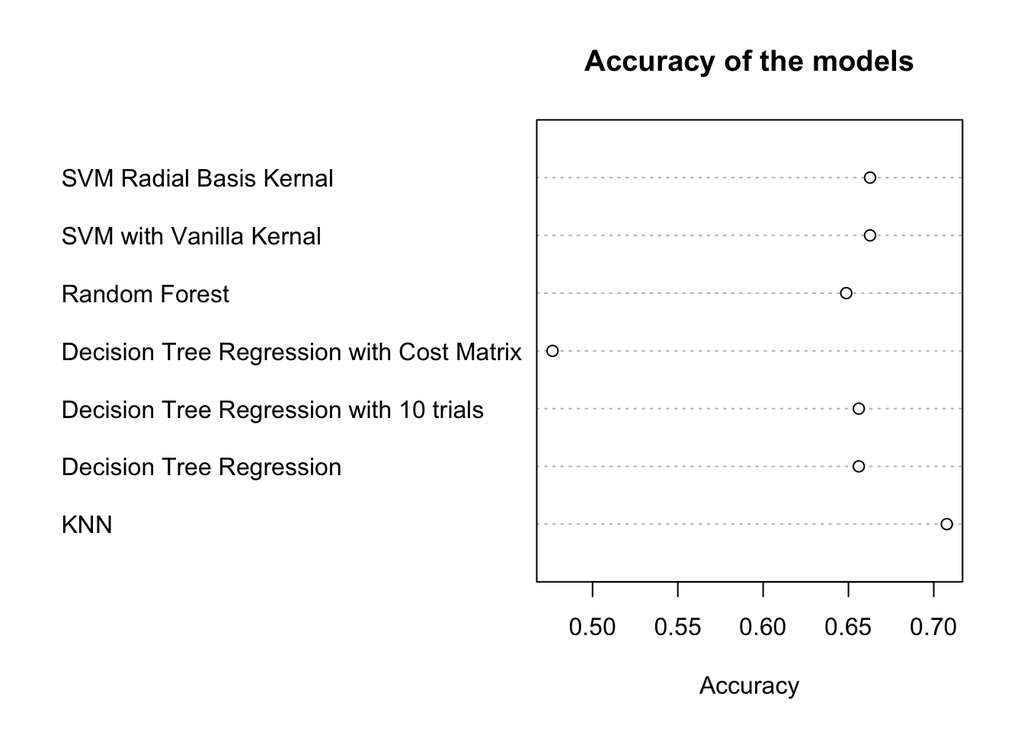

```r
dotchart(acc_predictions, labels = names, main = "Accuracy of the models", xlab = "Accuracy")
```